# Fuzzy Regression Discontinuity

This projectexamines the impact of a tutoring program designed for students with low entrance exam scores. The rule of the program is if students scoring below 70 are eligible for tutoring, while those scoring 70 or higher are not. But in practice, things don’t go wll and some eligible students do not participate, and some ineligible students still receive tutoring. This makes the setting a case of fuzzy regression discontinuity, where the cutoff influences the probability of treatment but does not determine it perfectly.

The main question is: does tutoring improve students’ performance on the exit exam, and if so, by how much?

The data are examined for compliance to find out how many students followed the rule, how many eligible students missed out, and how many ineligible students managed to get tutoring anyway. This step highlights the program’s imperfections, motivating the need for an instrumental variable approach.

To estimate the causal effect, the cutoff rule as an instrument for tutoring participation is used. First, a two-stage least squares (2SLS) strategy is implemented manually: the first stage predicts tutoring participation from being below the cutoff, and the second stage estimates how predicted tutoring affects exit exam scores. Then, the same design is implemented formally using an Instrumental Varaible(IV) regression model.

```r
library(tidyverse)
library(broom)
library(AER)
exam_data = read.csv("tutoring_program_fuzzy.csv")
exam_data
```

| id | entrance_exam | tutoring | tutoring_text | exit_exam |
| --- | --- | --- | --- | --- |
| 1 | 92.40833 | FALSE | No tutor | 78.07592 |
| 2 | 72.77238 | FALSE | No tutor | 58.21757 |
| 3 | 53.65090 | TRUE | Tutor | 61.96543 |
| 4 | 98.32688 | FALSE | No tutor | 67.48956 |
| 5 | 69.71219 | TRUE | Tutor | 54.12888 |
| 6 | 68.06771 | TRUE | Tutor | 60.13143 |
| 7 | 86.03048 | FALSE | No tutor | 73.05074 |
| 8 | 85.68573 | TRUE | Tutor | 76.73620 |
| 9 | 85.90494 | FALSE | No tutor | 57.78114 |
| 10 | 89.52848 | FALSE | No tutor | 79.91583 |

[output cut: 990 more lines]

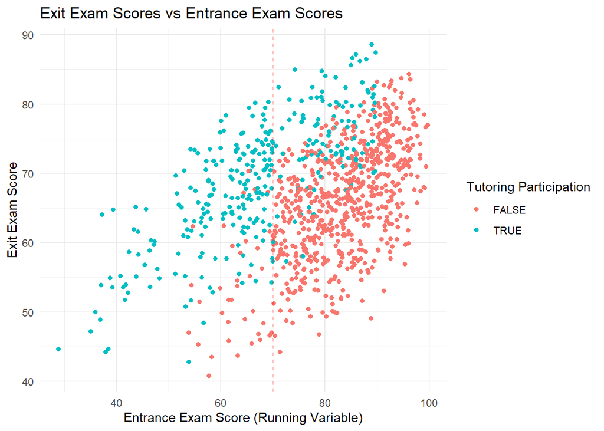

```r
ggplot(exam_data, aes(x = entrance_exam, y = exit_exam, color = tutoring)) +
  geom_point(position = position_jitter(width = 0, height = 0.2)) +
  geom_vline(xintercept = 70, linetype = "dashed", color = "red") +
  labs(
    title = "Exit Exam Scores vs Entrance Exam Scores",
    x = "Entrance Exam Score (Running Variable)",
    y = "Exit Exam Score",
    color = "Tutoring Participation"
  ) +
  theme_minimal()
```

```r
compliance_summary = exam_data %>%
  group_by(tutoring) %>%  # Grouping by the tutoring participation status
  summarize(
    count = n(),  # Counting the number of participants in each group
    percentage = (n() / nrow(exam_data)) * 100  # based on percentage
  )


compliance_summary
```

| tutoring | count | percentage |
| --- | --- | --- |
| FALSE | 682 | 68.2 |
| TRUE | 318 | 31.8 |

```r
threshold = 70

# misalignment with the program
misaligned_counts = exam_data %>%
  summarize(
    eligible_no_tutoring = sum(entrance_exam < threshold & tutoring == FALSE),#Qualified but did not use tutoring
    ineligible_with_tutoring = sum(entrance_exam >= threshold & tutoring == TRUE)#Ineligible but used tutoring
  )

misaligned_counts
```

| eligible_no_tutoring | ineligible_with_tutoring |
| --- | --- |
| 36 | 116 |

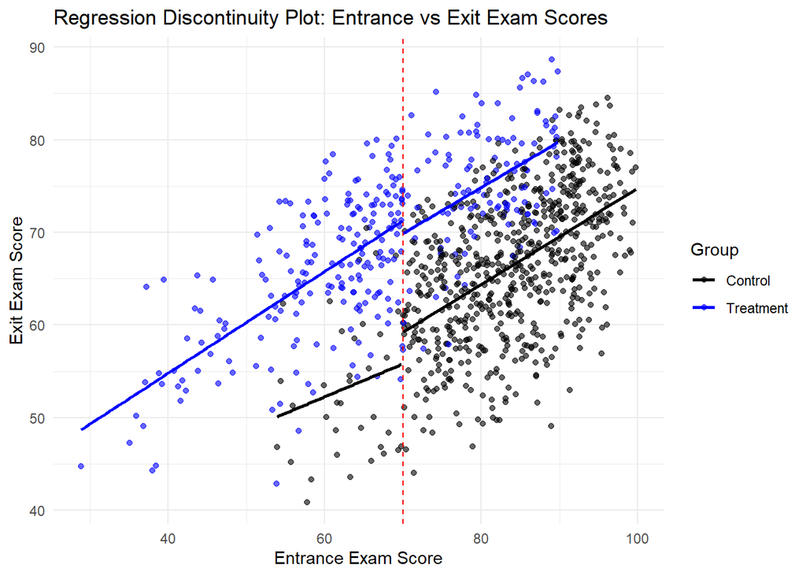

```r
threshold = 70

# RD plot
ggplot(exam_data, aes(x = entrance_exam, y = exit_exam, color = tutoring)) +
  geom_point(alpha = 0.6) +  # Scatter plot
  geom_vline(xintercept = threshold, linetype = "dashed", color = "red") +  # Threshold line
  geom_smooth(
    data = exam_data %>% filter(entrance_exam < threshold),
    method = "lm", se = FALSE, aes(group = tutoring),
    linetype = "solid"
  ) +  # Regression lines for below-threshold
  geom_smooth(
    data = exam_data %>% filter(entrance_exam >= threshold),
    method = "lm", se = FALSE, aes(group = tutoring),
    linetype = "solid"
  ) +  # Regression lines for above-threshold
  scale_color_manual(values = c("TRUE" = "blue", "FALSE" = "black"), labels = c("Control", "Treatment")) +
  labs(
    title = "Regression Discontinuity Plot: Entrance vs Exit Exam Scores",
    x = "Entrance Exam Score",
    y = "Exit Exam Score",
    color = "Group"
  ) +
  theme_minimal()
```

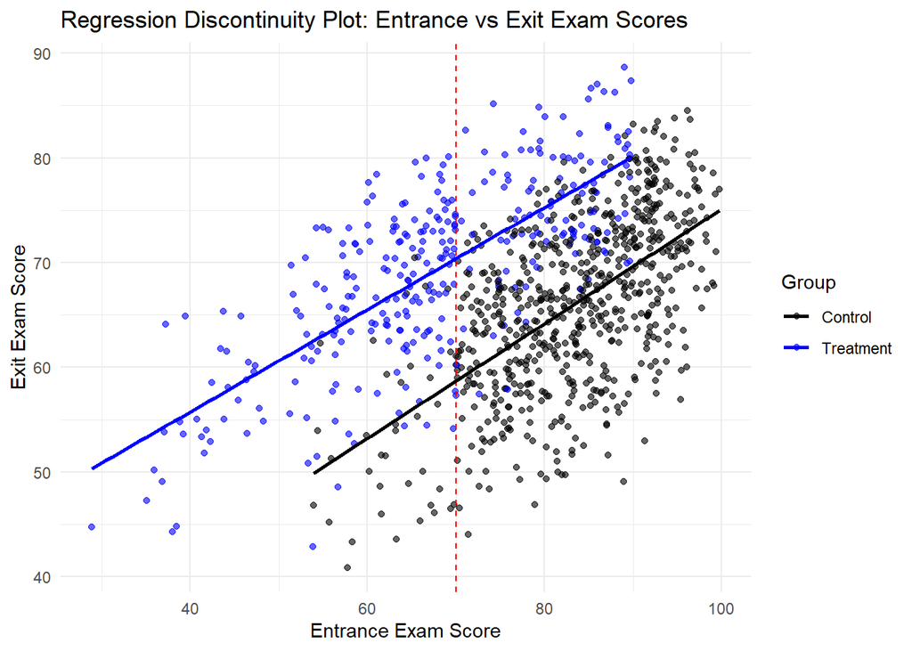

```r
threshold = 70

ggplot(exam_data, aes(x = entrance_exam, y = exit_exam, color = tutoring)) +
  geom_point(alpha = 0.6) +
  geom_vline(xintercept = threshold, linetype = "dashed", color = "red") +
  geom_smooth(method = "lm", se = FALSE) +
  scale_color_manual(values = c("TRUE" = "blue", "FALSE" = "black"), labels = c("Control", "Treatment")) +
  labs(
    title = "Regression Discontinuity Plot: Entrance vs Exit Exam Scores",
    x = "Entrance Exam Score",
    y = "Exit Exam Score",
    color = "Group"
  ) +
  theme_minimal()
```

It is fuzzy Regression Discontinuity because in the sharp RD , treatment assignment (tutoring) strictly and clearly determined by running variables (entrance exam). the cut off clearly show who should get the treatment and who should not. But fuzzy RD does not perfectly align with threshold and those one who should not receive the treatment get the treatment and those one who should get the treatment , don’t get that.

it means 1:because treatment status is not perfectly determined by the threshold, we cannot simply compare the average outcomes above and below the threshold to estimate the treatment effect and we need to approach estimation with the probability of treatment at the threshold and estimate the causal effect for individuals whose treatment is influenced by the threshold.so estimation would be probabilistic rather than deterministic. 2:we also need to pay specific attention to the subpopulation of compliers who are influenced by the threshold. because all the population is not divided cleraly based on cut off. 3:finally to estimate the treatment effect in a fuzzy RD, we need to account for the fact that treatment status is not perfectly determined by the threshold which involving using instrumental variables (IV) to address the fuzziness in treatment assignment.we can use two stage regression model in which in the the first stage we identifies the discontinuity in the probability of treatment at the threshold and then in the second stage we isolates the causal effect of treatment on the outcome (LATE). This approach allows us to estimate the treatment effect for the subpopulation of compliers.

```r
#Centering the running variable and estimate the LATE manually for a +/- 10 point window


# Centering the running variable
exam_data = exam_data %>%
  mutate(
    entrance_exam_centered = entrance_exam - 70,
    below_cutoff = ifelse(entrance_exam_centered < 0, 1, 0)
  )

# data in ±10 point window
exam_data_window = exam_data %>%
  filter(entrance_exam_centered >= -10 & entrance_exam_centered <= 10)

#  First-Stage Regression (Predict Tutoring Program Participation)
first_stage = lm(
  tutoring ~ entrance_exam_centered + below_cutoff,
  data = exam_data_window
)
exam_data_window = exam_data_window %>%
  mutate(tutoring_program_hat = predict(first_stage))

#  Second-Stage Regression (Outcome Regression)
second_stage = lm(
  exit_exam ~ entrance_exam_centered + tutoring_program_hat,
  data = exam_data_window
)


summary(first_stage)
```

```
##
## Call:
## lm(formula = tutoring ~ entrance_exam_centered + below_cutoff,
##     data = exam_data_window)
##
## Residuals:
##     Min      1Q  Median      3Q     Max
## -0.8558 -0.2105 -0.1548  0.1970  0.8671
##
## Coefficients:
##                        Estimate Std. Error t value Pr(>|t|)
## (Intercept)            0.132472   0.045137   2.935  0.00353 **
## entrance_exam_centered 0.011393   0.006939   1.642  0.10139
## below_cutoff           0.725841   0.079656   9.112  < 2e-16 ***
## ---
## Signif. codes:  0 '***' 0.001 '**' 0.01 '*' 0.05 '.' 0.1 ' ' 1
##
## Residual standard error: 0.3952 on 400 degrees of freedom
## Multiple R-squared:  0.3622, Adjusted R-squared:  0.359
## F-statistic: 113.6 on 2 and 400 DF,  p-value: < 2.2e-16
```

```r
summary(second_stage) # Second-stage results (LATE is the coefficient of tutoring_program_hat)
```

```
##
## Call:
## lm(formula = exit_exam ~ entrance_exam_centered + tutoring_program_hat,
##     data = exam_data_window)
##
## Residuals:
##      Min       1Q   Median       3Q      Max
## -21.6376  -5.3420   0.3136   5.5288  21.3741
##
## Coefficients:
##                        Estimate Std. Error t value Pr(>|t|)
## (Intercept)             60.1414     1.1789  51.016  < 2e-16 ***
## entrance_exam_centered   0.4366     0.1191   3.667 0.000279 ***
## tutoring_program_hat     9.7410     2.2144   4.399  1.4e-05 ***
## ---
## Signif. codes:  0 '***' 0.001 '**' 0.01 '*' 0.05 '.' 0.1 ' ' 1
##
## Residual standard error: 7.975 on 400 degrees of freedom
## Multiple R-squared:  0.04631,    Adjusted R-squared:  0.04154
## F-statistic: 9.712 on 2 and 400 DF,  p-value: 7.611e-05
```

```r
# Esimate the LATE using ivreg() using the same window.


exam_data = exam_data %>%
  mutate(
    entrance_exam_centered = entrance_exam - 70,
    below_cutoff = ifelse(entrance_exam_centered < 0, 1, 0)
  )


exam_data_window = exam_data %>%
  filter(entrance_exam_centered >= -10 & entrance_exam_centered <= 10)

# LATE using Instrumental Variables Regression
iv_model = ivreg(
  exit_exam ~ entrance_exam_centered + tutoring | entrance_exam_centered + below_cutoff,
  data = exam_data_window
)


summary(iv_model)
```

```
##
## Call:
## ivreg(formula = exit_exam ~ entrance_exam_centered + tutoring |
##     entrance_exam_centered + below_cutoff, data = exam_data_window)
##
## Residuals:
##      Min       1Q   Median       3Q      Max
## -17.1782  -4.5367   0.3994   4.8710  13.3955
##
## Coefficients:
##                        Estimate Std. Error t value Pr(>|t|)
## (Intercept)             60.1414     0.9622  62.503  < 2e-16 ***
## entrance_exam_centered   0.4366     0.0972   4.492 9.24e-06 ***
## tutoringTRUE             9.7410     1.8074   5.390 1.21e-07 ***
## ---
## Signif. codes:  0 '***' 0.001 '**' 0.01 '*' 0.05 '.' 0.1 ' ' 1
##
## Residual standard error: 6.509 on 400 degrees of freedom
## Multiple R-Squared: 0.3646,  Adjusted R-squared: 0.3615
## Wald test: 14.58 on 2 and 400 DF,  p-value: 7.746e-07
```

The result shows that both approaches (2SLS and IV) produce consistent results in which tutoring increases exit exam performance by roughly 9 to 10 points for students near the cutoff.

The key takeaway is that, despite imperfect compliance, the eligibility rule provides a credible source of variation that allows us to measure the causal impact of tutoring. The result is showing the impact of the Local Average Treatment Effect (LATE) which highlight the role of tutoring(treatment) for students whose participation was influenced by being just below the cutoff.

This project shows that tutoring has a clear and significant positive effect on student outcomes, raising exit exam scores by nearly 10 points for borderline students, and it demonstrates how fuzzy regression discontinuity can be used to evaluate real-world programs when rules are not followed perfectly.